# PfSPZ Take Leading Edges from a GSEA Table to Make an Upset Plot

Tuan M. Tran

2/23/2022

```r
library(tidyverse)
library(knitr)
library(ggplot2)
library(googledrive)
library(EDASeq)
knitr::opts_chunk$set(echo = TRUE)
```

## Objective

This markdown shows how to convert data to format required for UpSet Plot (See: https://cran.r-project.org/web/packages/UpSetR/vignettes/basic.usage.html)

Per usage in vignette, UpSet requires a dataframe by which the first column if the feature and subsequent columns include “sets” with inclusion of each feature within a set as either 1 (included) or 0 (not included). See ?UpSetR::upset

Since our goal is to have features (leading edges) as rows and genesets as columns, one approach to solve this is to convert leading edge vectors for each pathway/module into two-column dataframes with the first column being the leading edge and the second column coded as “1” and the pathway/module as the column name. Then, a FULL join of all two-column dataframes can be performed while converting NAs into “0”.

Here it is complicated by the fact that we have different comparisons for each treatment group. Thus, each pathway/module will have to be replicated for each treatment. Since we are only concerned with Placebo and high-dose PfSPZ in our case, we will have two per pathway. Also, we only care about flipped pathways that are significant (FDR<20%).

## Downselect based on leading edges

Getting leading edges from baseline DGE analysis, then filter pathway/modules that are signficant and relevant.

```r
gsea_LE <- readxl::read_excel("/Volumes/GoogleDrive/My Drive/Manuscripts/KSPZV1 Manuscript/Med Revised Submission 2022/Supplementary Tables/Table SX Prevax GSEA Tables for KSPZV1 revision.xlsx") %>%
  dplyr::filter(module_type %in% c("highBTMs", "lowBTMs", "MonacoModules", "BloodGen3Module"))

#Pull out flipped pathways with FDR <20% from Placebo and High-dose
gsea_LE_filtered <- gsea_LE %>%
  filter(treatment %in% c("Placebo", "1.8 x 10^6 PfSPZ")) %>% #only placebo and highdose
  mutate(treatment = gsub("1\\.8 x 10\\^6 PfSPZ", "high_dose_PfSPZ", treatment)) %>% #rename highdose to syntactically valid name
  filter(padj<0.20) #FDR cutoff
gsea_LE_filtered2 <- gsea_LE_filtered %>%
    filter(duplicated(pathway)|duplicated(pathway, fromLast=TRUE)) %>% #only pathways in common
  arrange(pathway) %>%
  dplyr::select(-c(ES, size, pval, padj, module_type, leadingEdge)) %>% #remove unwanted columns (will join back later)
  pivot_wider(., names_from = treatment, values_from = NES) %>%
  filter(sign(Placebo) != sign(high_dose_PfSPZ)) %>% #filter only "'flipped" normalized enrichment scores
  pivot_longer(cols = 2:3, names_to = "treatment", values_to = "NES") %>%
  dplyr::select(-c(NES)) %>%
  left_join(., gsea_LE_filtered, by = c("pathway", "treatment"))  #join with original gsea_LE dataframe
```

```r
#paste pathway and treatment to create a new variable.  This will eventually become the column names
gsea_LE_filtered3 <- gsea_LE_filtered2 %>%
  mutate(pathway_treat = paste(pathway, treatment, sep = " ")) %>%
  dplyr::select(pathway_treat, module_type, leadingEdge) %>%
  filter(module_type == "highBTMs") %>% #filter here if to limit to specific modules
  column_to_rownames(var = "pathway_treat") %>%
  data.frame()

#loop to convert into list of dataframes with features as rows and second column name as pathway/module
myList <- sapply(rownames(gsea_LE_filtered3),function(x) NULL)
for(i in 1:nrow(gsea_LE_filtered3)){
  myList[[i]] <- data.frame("LeadingEdge" = unlist(str_split(gsea_LE_filtered3[i,]$leadingEdge,  ", ")), "TempName" = 1)
  names(myList[[i]])[names(myList[[i]]) == 'TempName'] <- names(myList[i])
}

#use join_all to join all dataframes in list, with type set to "full"
upset.df <- plyr::join_all(myList, by = "LeadingEdge", type = "full")

#clean up column names
colnames(upset.df) <- gsub("high_dose_PfSPZ", "1.8x10^6 PfSPZ", colnames(upset.df))

#convert NAs to zeros
upset.df[is.na(upset.df)] <- 0
```

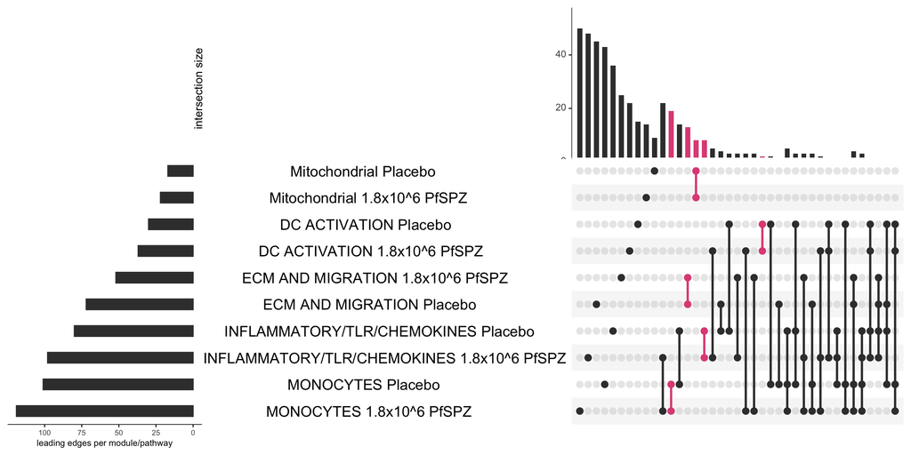

```r
library(UpSetR)
upset.df %>%
  dplyr::filter() %>%
  upset(. , nsets = ncol(.)-1, number.angles = 30, show.numbers = "no", point.size = 3, line.size = 1,
    mainbar.y.label = "intersection size", sets.x.label = "leading edges per module/pathway",

    queries = list(
      list(
        query = intersects,
        params = list("MONOCYTES Placebo", "MONOCYTES 1.8x10^6 PfSPZ"), list("INFLAMMATORY/TLR/CHEMOKINES Placebo", "INFLAMMATORY/TLR/CHEMOKINES 1.8x10^6 PfSPZ"),
        color = "#Df5286",
        active = T,
        query.name = "Intersection between Placebo and 1.8x10^6 PfSPZ"
        ),
      list(
        query = intersects,
        params = list("INFLAMMATORY/TLR/CHEMOKINES Placebo", "INFLAMMATORY/TLR/CHEMOKINES 1.8x10^6 PfSPZ"),
        color = "#Df5286",
        active = T,
        query.name = "Intersection between Placebo and 1.8x10^6 PfSPZ"
        ),
      list(
        query = intersects,
        params = list("DC ACTIVATION Placebo", "DC ACTIVATION 1.8x10^6 PfSPZ"),
        color = "#Df5286",
        active = T,
        query.name = "Intersection between Placebo and 1.8x10^6 PfSPZ"
        ),
      list(
        query = intersects,
        params = list("ECM AND MIGRATION Placebo", "ECM AND MIGRATION 1.8x10^6 PfSPZ"),
        color = "#Df5286",
        active = T,
        query.name = "Intersection between Placebo and 1.8x10^6 PfSPZ"
        ),
      list(
        query = intersects,
        params = list("Mitochondrial Placebo", "Mitochondrial 1.8x10^6 PfSPZ"),
        color = "#Df5286",
        active = T,
        query.name = "Intersection between Placebo and 1.8x10^6 PfSPZ"
        )
      ),
    text.scale = c(1.3, 1.3, 1, 1, 2, 0.75),
    mb.ratio = c(0.35,0.65))
```